# IE_360_Assignment1_Erce_Sezgun

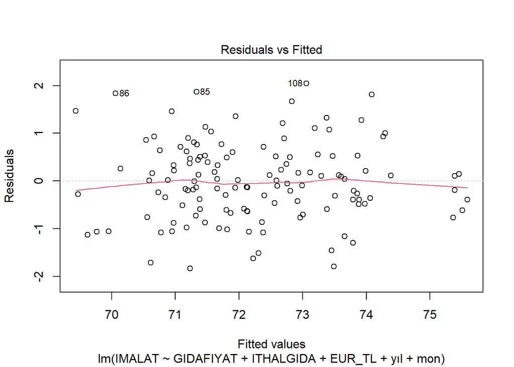

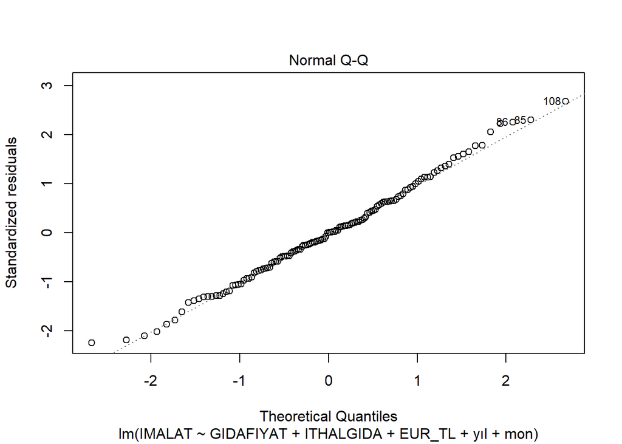

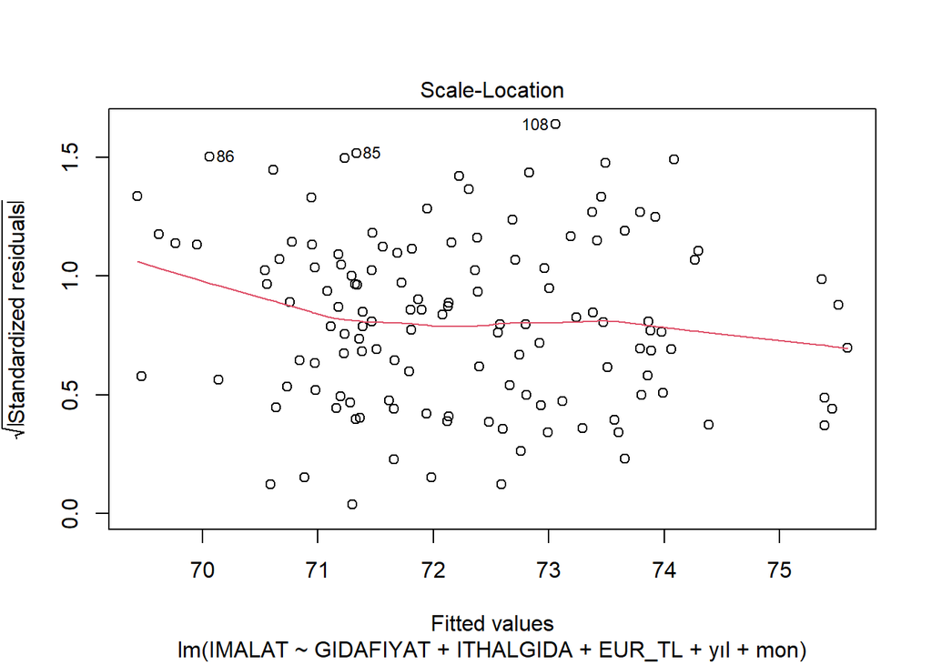

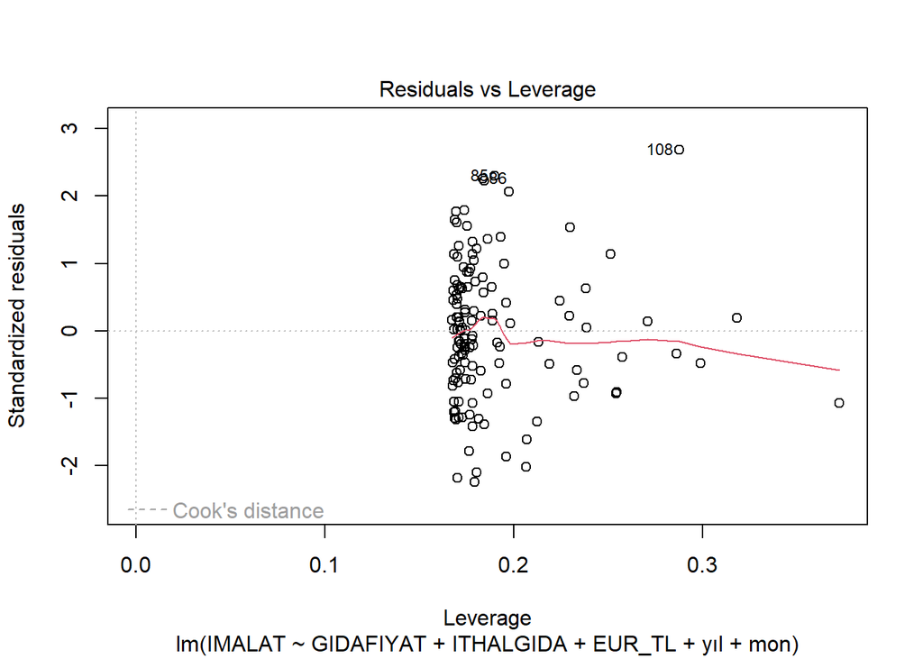

```r
plot(l_fit)
```

- R value is not as high as the previously made models, that may tell us that independent variables were not that explanatory at some parts for our data.

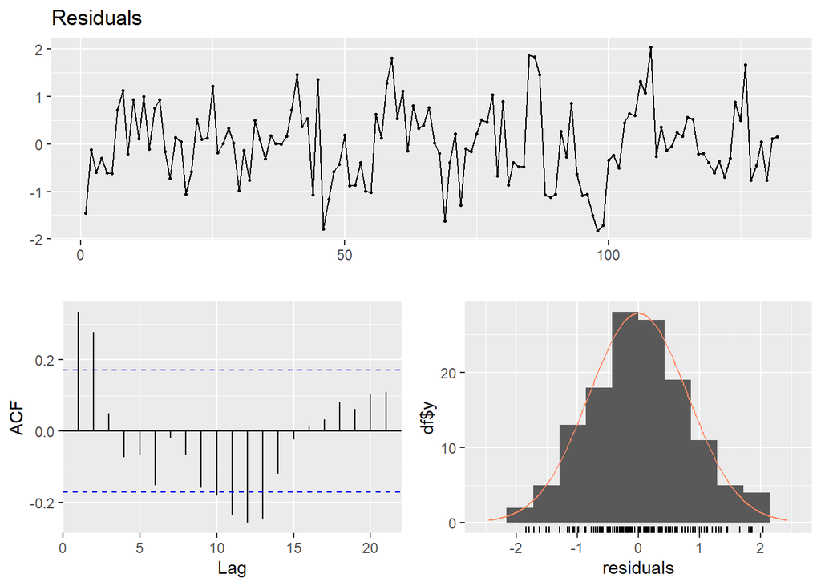

```
##
##  Breusch-Godfrey test for serial correlation of order up to 12
##
## data:  Residuals
## LM test = 42.664, df = 12, p-value = 2.574e-05
```

```r
checkresiduals(l_fit,12)
```

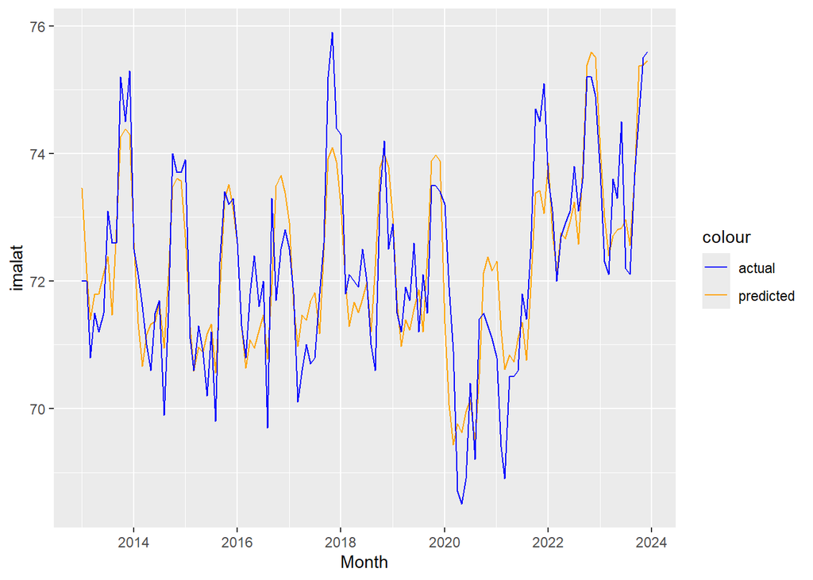

```r
gıda$fitted <- fitted(l_fit)
gıda$residual <- residuals(l_fit)
cols <- c("predicted" = "orange","actual" = "blue")
ggplot() +
  geom_line(data = gıda, aes(x = Tarih,y = fitted, color = "predicted")) +
  geom_line(data = gıda, aes(x = Tarih,y = IMALAT, color = "actual")) +
  xlab("Month") +
  ylab("imalat") +
  scale_color_manual(values = cols)
```

## Conclusion

In conclusion we made three models that are using different dependent variables with their respective independent variables. All the dependent variables had seasonality related to their data. Logarithm of the Accommodation data had to be taken to neutralize the increase in the variation. On the other hand all the models have negatively affected by the Covid period data as my models could not reason the fall in the data in that period.